# Most harmful event with respect to health and economic

Frank Guan

November 3, 2016

## Synopsis

Storms and other severe weather events, tornadoes, excessive heat, and flash floods can cause both public health and economic problems.

Many severe events, tornadoes, thunderstorm winds, and flash floods can result in fatalities, injuries, and property damage, and preventing such outcomes to the extent possible is a key concern..

References:

[1]: [National Weather Service Storm Data Documentation](https://d396qusza40orc.cloudfront.net/repdata%2Fpeer2_doc%2Fpd01016005curr.pdf)

[2]: [National Climatic Data Center Storm Events FAQ](https://d396qusza40orc.cloudfront.net/repdata%2Fpeer2_doc%2FNCDC%20Storm%20Events-FAQ%20Page.pdf)

## Data Processing

Load data.

```r
stormData = read.csv(bzfile("repdata-data-StormData.csv.bz2"), header = TRUE)
```

Select the columns.

```r
subStormData <-
        stormData[,c("EVTYPE", "FATALITIES", "INJURIES", "PROPDMG")]
```

Make event names meanful.

```r
subStormData$EVTYPE <-
    gsub("^HEAT$", "EXCESSIVE HEAT", subStormData$EVTYPE)
subStormData$EVTYPE <-
    gsub("^TSTM WIND$", "MARINE THUNDERSTORM WIND", subStormData$EVTYPE)
```

Find the top 10 events of fatalities.

```r
fatalitiesData <-
        aggregate(subStormData$FATALITIES,
                by=list(subStormData$EVTYPE), FUN=sum, na.rm=TRUE)
colnames(fatalitiesData) = c("eventType", "fatalityTotal")
fatalitiesSorted <-
    fatalitiesData[order(-fatalitiesData$fatalityTotal),]
topfatalities <- fatalitiesSorted[1:10,]
topfatalities$eventType <-
    factor(
        topfatalities$eventType, levels=topfatalities$eventType,
        ordered=TRUE)
```

Do the top 10 events of injuries.

```r
injuriesData <-
        aggregate(subStormData$INJURIES,
                by=list(subStormData$EVTYPE), FUN=sum, na.rm=TRUE)
colnames(injuriesData) = c("eventType", "injuryTotal")
injuriesSorted <- injuriesData[order(-injuriesData$injuryTotal),]
topInjuries <- injuriesSorted[1:10,]
topInjuries$eventType <-
    factor( topInjuries$eventType, levels=topInjuries$eventType,
        ordered=TRUE)
```

Do the top 10 events of property damage.

```r
propDmgData <-
        aggregate(subStormData$PROPDMG,
                by=list(subStormData$EVTYPE), FUN=sum, na.rm=TRUE)
colnames(propDmgData) = c("eventType", "propDmgTotal")
propDmgSorted <- propDmgData[order(-propDmgData$propDmgTotal),]
topPropDmg <- propDmgSorted[1:10,]
topPropDmg$eventType <-
    factor(
        topPropDmg$eventType, levels=topPropDmg$eventType,
        ordered=TRUE)
```

## Results

Plot the top 10 types of events for fatalities.

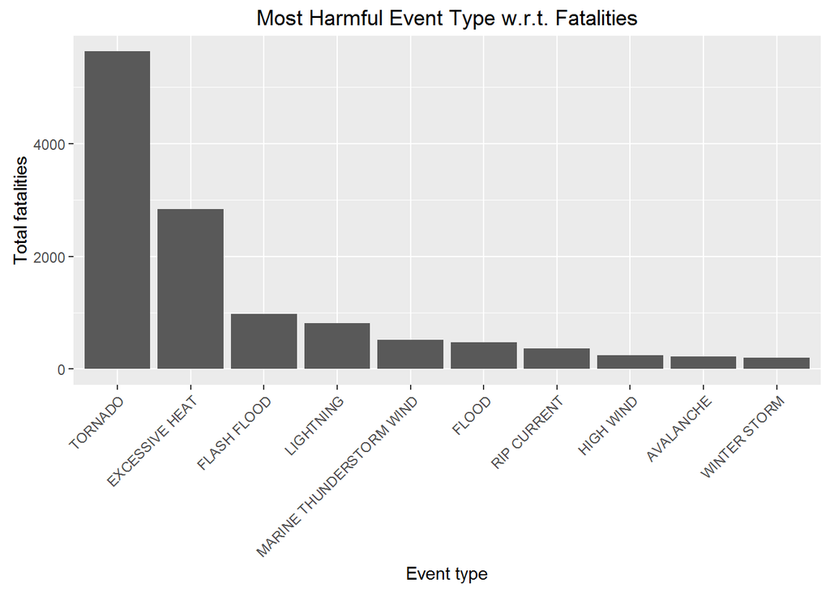

```r
library(ggplot2)
ggplot(data=topfatalities, aes(x=eventType, y=fatalityTotal)) +
    geom_bar(stat="identity") + xlab("Event type") + ylab("Total fatalities") +
    ggtitle("Most Harmful Event Type w.r.t. Fatalities") +
    theme(axis.text.x = element_text(angle = 45, hjust = 1))
```

Plot the top 10 types of events for injuries.

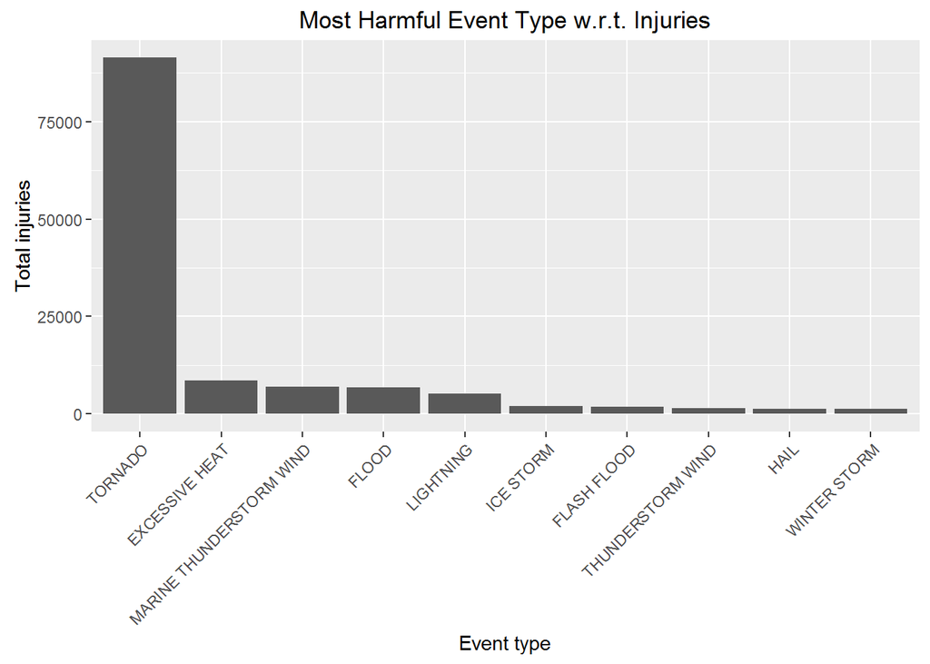

```r
ggplot(data=topInjuries, aes(x=eventType, y=injuryTotal)) +
    geom_bar(stat="identity") + xlab("Event type") + ylab("Total injuries") +
    ggtitle("Most Harmful Event Type w.r.t. Injuries") +
    theme(axis.text.x = element_text(angle = 45, hjust = 1))
```

Plot the top 10 types of events for property damage.

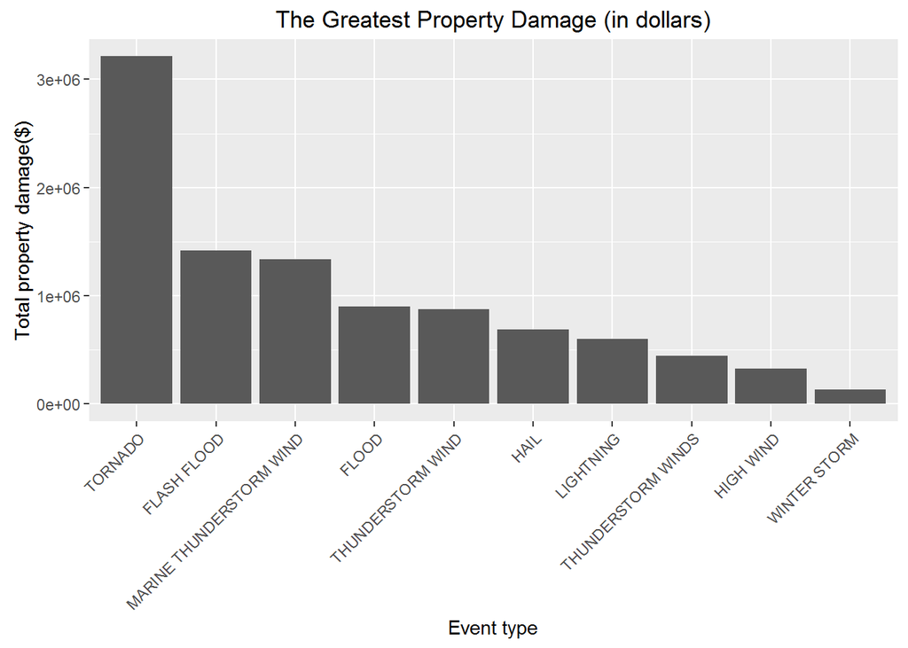

```r
ggplot(data=topPropDmg, aes(x=eventType, y=propDmgTotal)) +
    geom_bar(stat="identity") + xlab("Event type") +
    ylab("Total property damage($)") +  ggtitle("The Greatest Property Damage (in dollars)") +
    theme(axis.text.x = element_text(angle = 45, hjust = 1))
```